# Modelos de Equações Estruturais Longitudinais

## AGENDA

### Modelos de Equações Estruturais Longitudinais

- **Análise Fatorial Confirmatória (CFA) com dados longitudinais**
- **Invariância de Medida (MI) longitudinal**
- **Exercício prático - Parte 1**
- **Modelos de Crescimento Latente (LGC)**
- **Exercício prático - Parte 2**

## CFA com dados longitudinais

## CFA e Modelo de medida (recap)

A CFA permite avaliar se um determinado modelo de medida teórico se ajusta a um conjunto de dados

- O modelo CFA representa as relações entre uma ou mais variáveis latentes ou fatores e os seus indicadores observados
  - A CFA foi abordada anteriormente com dados transversais

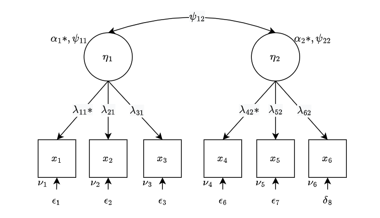

## CFA Multigrupo

### CFA multigrupo permite avaliar o ajustamento de modelo de medida a diferentes subgrupos da população (ex.: género, coortes, contextos culturais)

### A CFA multigrupo pode ser generalizada a longitudinais, correspondendo os grupos a diferentes momentos de avaliação

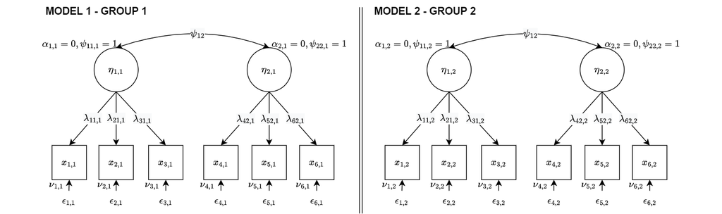

## CFA Longitudinal

### A CFA longitudinal permite testar se a estrutura de um modelo de medida se mantém estável ao longo do tempo

### Avalia se os construtos latentes são **medidos de forma consistente ao longo do tempo**

- Essencial para análises longitudinais como:
  - Modelos de crescimento latente (LGM)
  - Modelos de painel
  - …

## CFA Longitudinal

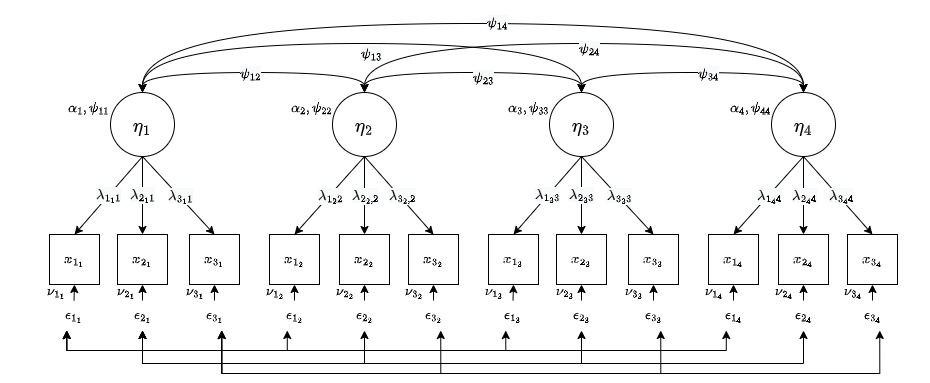

## CFA Longitudinal - implementação

Para as análises seguintes recorremos a uma base de dados usada por Todd Little no livro:  
- Little, T. (2013). *Longitudinal structural equation modeling*. New York, NY: Guilford Press.

Este livro é um bom recurso para conhecer e aplicar procedimentos SEM a dados longitudinais

[figure not shown]

## Importação e exploração inicial dos dados

Podemos importar a base de dados para o R através do seguinte código

```r
DF_mood <- read.csv("G:\\My Drive\\FPCEUP\\AtividadeDocente\\Longitudinal_SEM\\LongSEM_Data\\df_mood.csv")
names(DF_mood)
```

```
##  [1] "PosAFF11" "PosAFF21" "PosAFF31" "NegAFF11" "NegAFF21" "NegAFF31"
##  [7] "PosAFF12" "PosAFF22" "PosAFF32" "NegAFF12" "NegAFF22" "NegAFF32"
## [13] "PosAFF13" "PosAFF23" "PosAFF33" "NegAFF13" "NegAFF23" "NegAFF33"
```

```r
str(DF_mood)
```

## Estatística descritiva

```r
library(psych) # se necessário: install.packages("psych")
psych::describe(DF_mood[ ,1:6])
```

```
##          vars   n mean   sd median trimmed  mad  min  max range  skew kurtosis
## PosAFF11    1 368 3.21 0.72   3.24    3.22 0.76 1.00 5.43  4.43 -0.09    -0.21
## PosAFF21    2 368 3.11 0.74   3.14    3.11 0.75 1.00 5.27  4.27 -0.06     0.06
## PosAFF31    3 368 3.25 0.75   3.24    3.24 0.77 1.00 5.30  4.30  0.06    -0.21
## NegAFF11    4 368 1.52 0.65   1.47    1.51 0.71 0.12 3.57  3.46  0.29    -0.18
## NegAFF21    5 368 1.40 0.57   1.37    1.38 0.56 0.00 3.28  3.28  0.26     0.02
## NegAFF31    6 368 1.40 0.60   1.36    1.39 0.59 0.00 3.11  3.11  0.20    -0.23
##            se
## PosAFF11 0.04
## PosAFF21 0.04
## PosAFF31 0.04
## NegAFF11 0.03
## NegAFF21 0.03
## NegAFF31 0.03
```

## Visualização de dados

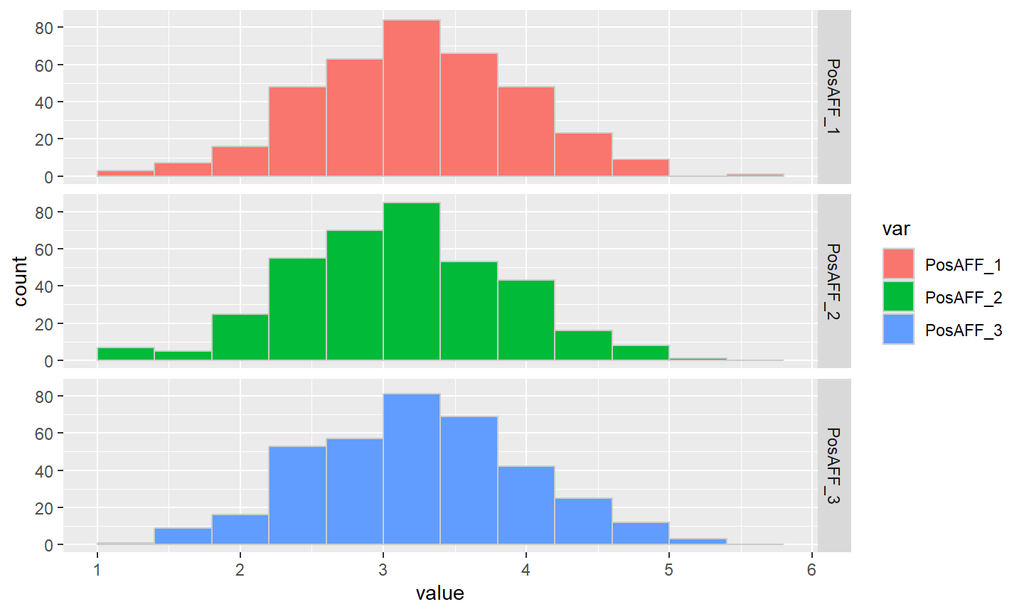

```r
library(ggplot2) # se necessário: install.packages("ggplot2")
DF_pos <- data.frame(var=c(rep("PosAFF_1", 368), rep("PosAFF_2", 368), rep("PosAFF_3", 368)),
                     value = c(DF_mood$PosAFF11, DF_mood$PosAFF21, DF_mood$PosAFF31))
ggplot(DF_pos, aes(x=value)) +
  geom_histogram(aes(fill=var),color="grey80", binwidth = 0.4) + facet_grid(var~.)
```

## Visualização de dados

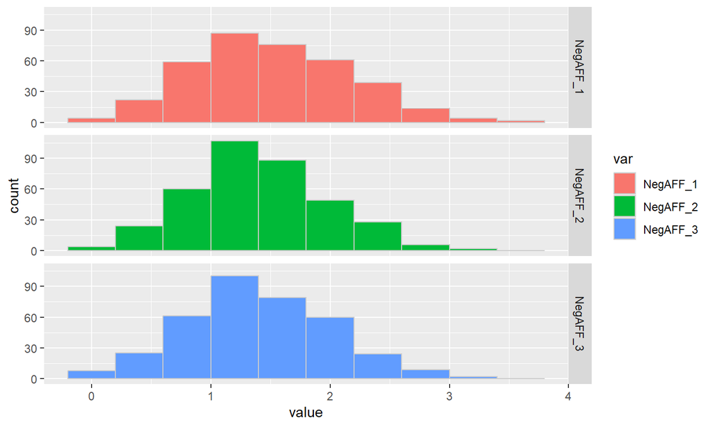

```r
DF_neg <- data.frame(var=c(rep("NegAFF_1", 368), rep("NegAFF_2", 368), rep("NegAFF_3", 368)),
                     value = c(DF_mood$NegAFF11, DF_mood$NegAFF21, DF_mood$NegAFF31))
ggplot(DF_neg, aes(x=value)) +
  geom_histogram(aes(fill=var),color="grey80", binwidth = 0.4) + facet_grid(var~.)
```

## Modelo CFA longitudinal - especificação

O seguinte código representa a estrutura fatorial de um modelo com:  
- 2 VL, humor positivo e humor negativo  
- 3 indicadores por VL  
- 3 momentos de avaliação

Aspeto diferenciador: **correlações entre resíduos dos mesmos indicadores avaliados em momentos diferentes**  
- Existência de variabilidade especifica ao item que é partilhada entre os diferentes momentos de avaliação

*NOTA. Estas correlações devem ser mantidas no modelo mesmo que não sejam significativas*

## Modelo CFA longitudinal - especificação

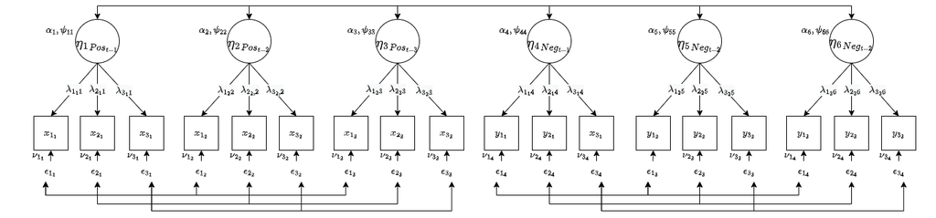

## Modelo CFA longitudinal

A seguinte sintaxe especifica o modelo no lavaan:

```r
modelo.7 <- "
# Definir variáveis latentes para os 3 momentos
Pos_T1 =~ PosAFF11 + PosAFF21 + PosAFF31
Pos_T2 =~ PosAFF12 + PosAFF22 + PosAFF32
Pos_T3 =~ PosAFF13 + PosAFF23 + PosAFF33

Neg_T1 =~ NegAFF11 + NegAFF21 + NegAFF31
Neg_T2 =~ NegAFF12 + NegAFF22 + NegAFF32
Neg_T3 =~ NegAFF13 + NegAFF23 + NegAFF33

# Correlações entre resíduos ao longo do tempo
PosAFF11 ~~ PosAFF12 + PosAFF13; PosAFF12 ~~ PosAFF13
PosAFF21 ~~ PosAFF22 + PosAFF23; PosAFF22 ~~ PosAFF23
PosAFF31 ~~ PosAFF32 + PosAFF33; PosAFF32 ~~ PosAFF33

NegAFF11 ~~ NegAFF12 + NegAFF13; NegAFF12 ~~ NegAFF13
NegAFF21 ~~ NegAFF22 + NegAFF23; NegAFF22 ~~ NegAFF23
NegAFF31 ~~ NegAFF32 + NegAFF33; NegAFF32 ~~ NegAFF33
"
fit.7 <- cfa(modelo.7, data = DF_mood, meanstructure=T, std.lv=T)
```

## Modelo CFA longitudinal (avaliação)

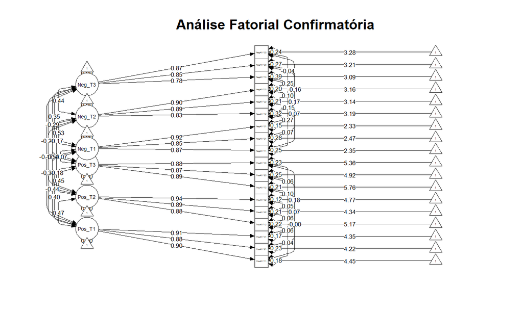

```r
summary(fit.7, standardized=TRUE, fit.measures=TRUE, rsquare = TRUE)
fitMeasures(fit.7)
reliability(fit.7)
semTools::clipboard(fit.7)
```

## Invariância de Medida (MI) longitudinal

## O que é MI (recap))?

### Teste formal do pressuposto de equivalência entre medições

- *Será que os construtos em análise são comparáveis entre condições?*

### Geralmente conduzida por meio de comparação de modelos encaixados

### Níveis de MI

1. **Invariância Configural** - os grupos interpretam o construto de forma semelhante;
2. **Invariância Métrica** - os itens têm o mesmo peso;
3. **Invariância Escalar** - os items têm a mesma “dificuldade”;
4. **Invariância Estrita** - os items têm a mesma precisão.

## Comparação de modelos

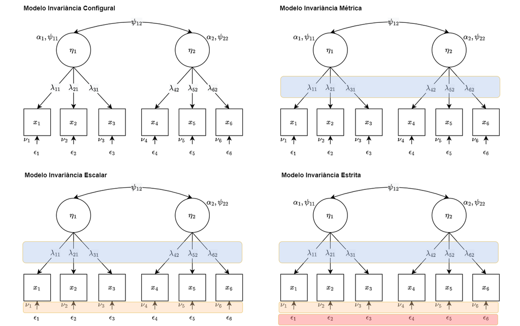

## Comparação de modelos encaixados

### Teste formal: Likelihood Ratio Test (**LRT**) para modelos encaixados

- avalia se **o modelo mais restrito (com menos parâmetros) se ajusta aos dados significativamente pior do que o modelo menos restrito**

### Outras métricas de comparação de modelos (Cheung & Rensvold, 2002)

- **ΔCFI < 0.01**
- **ΔRMSEA < 0.015**
- **ΔSRMR < 0.03**

## O que é MI Longitudinal?

### Refere-se à estabilidade das propriedades psicométricas de um instrumento ao longo do tempo

### Garante que **mudanças nos valores da variável latentes** refletem mudanças reais no construto *e não alterações na forma como o construto é medido*

### Baseia-se na lógica da CFA multigrupo, onde os “grupos” são os diferentes **momentos de avaliação**

## Porquê testar invariância longitudinal?

### Sem invariância, não podemos comparar **valores fatoriais**, **tendências de crescimento** ou **efeitos longitudinais** de forma válida

- Avaliar estabilidade do construto
- Identificar mudanças reais nos participantes
- Garantir a validade de modelos de crescimento e trajetórias latentes

## Níveis de Invariância Longitudinal

### 1. *Configuracional* - Mesma estrutura fatorial ao longo do tempo

### 2. *Fraca ou Métrica* - Pesos fatoriais (loadings) constantes

### 3. *Forte ou Escalar* - Loadings e interceptos constantes

### 4. *Estrita* - loadings, interceptos e resíduos dos itens constantes

- **Estes níveis são comparados sequencialmente**
  - Primeiro modelo livre (configural)
  - Depois adicionam-se restrições métricas, escalares, etc.
  - Avaliamos mudança no ajuste do modelo: \(\Delta{CFI}\), \(\Delta{RMSEA}\), \(\Delta\chi^2\)

### Ferramentas comuns: lavaan em R; Mplus; AMOS

## IM Longitudinal (implementação no lavaan)

Existem várias formas de implementar a MI longitudinal no lavaan.

### Definindo explícita dos modelos (recomendada)

- Esta abordagem oferece controle sobre o processo de modelagem, permitindo especificar manualmente as restrições necessárias para cada nível de invariância.

### Através da função **measEq.syntax()** do pacote semTools

- Esta função automatiza a geração da sintaxe do modelo para testar diferentes níveis de invariância, simplificando o processo e reduzindo a possibilidade de erros manuais.

## Modelo Configuracional - especificação

### Pacotes necessários

```r
library(lavaan) # se necessário: install.packages("lavaan")
library(semTools) # se necessário: install.packages("semTools")
library(semPlot) # se necessário: install.packages("semPlot")
```

```r
modelo.conf <- "
# Definir variáveis latentes para os 3 momentos
Pos_T1 =~ PosAFF11 + PosAFF21 + PosAFF31
Pos_T2 =~ PosAFF12 + PosAFF22 + PosAFF32
Pos_T3 =~ PosAFF13 + PosAFF23 + PosAFF33
Neg_T1 =~ NegAFF11 + NegAFF21 + NegAFF31
Neg_T2 =~ NegAFF12 + NegAFF22 + NegAFF32
Neg_T3 =~ NegAFF13 + NegAFF23 + NegAFF33

# Correlações entre resíduos ao longo do tempo
PosAFF11 ~~ PosAFF12 + PosAFF13; PosAFF12 ~~ PosAFF13;
PosAFF21 ~~ PosAFF22 + PosAFF23; PosAFF22 ~~ PosAFF23;
PosAFF31 ~~ PosAFF32 + PosAFF33; PosAFF32 ~~ PosAFF33
NegAFF11 ~~ NegAFF12 + NegAFF13; NegAFF12 ~~ NegAFF13;
NegAFF21 ~~ NegAFF22 + NegAFF23; NegAFF22 ~~ NegAFF23;
NegAFF31 ~~ NegAFF32 + NegAFF33; NegAFF32 ~~ NegAFF33
"
```

## IM Configuracional - estimação

### Estimar o modelo como habitualmente, com a função **cfa()** do lavaan

```r
fit.conf <- cfa(modelo.conf, data = DF_mood, std.lv = T, missing = "fiml", estimator="MLR")
# summary(fit.conf, standardized=TRUE, fit.measures=TRUE, rsquare = TRUE)
all_params <- parameterEstimates(fit.conf, standardized = TRUE, rsquare = TRUE)
head(all_params[all_params$op == "=~", ])
```

```
##      lhs op      rhs   est    se      z pvalue ci.lower ci.upper std.lv std.all
## 1 Pos_T1 =~ PosAFF11 0.652 0.029 22.788      0    0.596    0.708  0.652   0.903
## 2 Pos_T1 =~ PosAFF21 0.644 0.032 20.394      0    0.582    0.706  0.644   0.875
## 3 Pos_T1 =~ PosAFF31 0.681 0.029 23.112      0    0.623    0.739  0.681   0.911
## 4 Pos_T2 =~ PosAFF12 0.556 0.029 19.242      0    0.500    0.613  0.556   0.883
## 5 Pos_T2 =~ PosAFF22 0.638 0.029 22.010      0    0.581    0.695  0.638   0.887
## 6 Pos_T2 =~ PosAFF32 0.644 0.029 21.877      0    0.587    0.702  0.644   0.939
##   std.nox
## 1   0.903
## 2   0.875
## 3   0.911
## 4   0.883
## 5   0.887
## 6   0.939
```

## IM Configuracional - avaliação

```r
fitMeasures(fit.conf, c("chisq.scaled", "df.scaled", "pvalue.scaled", "rmsea.robust",
                        "rmsea.ci.lower.robust", "rmsea.ci.upper.robust", "cfi.robust",
                        "tli.robust", "srmr_mplus"))
```

```
##          chisq.scaled             df.scaled         pvalue.scaled
##               119.400               102.000                 0.115
##          rmsea.robust rmsea.ci.lower.robust rmsea.ci.upper.robust
##                 0.021                 0.000                 0.036
##            cfi.robust            tli.robust            srmr_mplus
##                 0.997                 0.995                 0.027
```

## IM Métrica - especificação

```r
modelo.metric <- "
# Definir variáveis latentes para os 3 momentos
Pos_T1 =~ L1.1*PosAFF11 + L1.2*PosAFF21 + L1.3*PosAFF31
Pos_T2 =~ L1.1*PosAFF12 + L1.2*PosAFF22 + L1.3*PosAFF32
Pos_T3 =~ L1.1*PosAFF13 + L1.2*PosAFF23 + L1.3*PosAFF33
Neg_T1 =~ L2.1*NegAFF11 + L2.2*NegAFF21 + L2.3*NegAFF31
Neg_T2 =~ L2.1*NegAFF12 + L2.2*NegAFF22 + L2.3*NegAFF32
Neg_T3 =~ L2.1*NegAFF13 + L2.2*NegAFF23 + L2.3*NegAFF33

# Correlações entre resíduos ao longo do tempo
PosAFF11 ~~ PosAFF12 + PosAFF13; PosAFF12 ~~ PosAFF13;
PosAFF21 ~~ PosAFF22 + PosAFF23; PosAFF22 ~~ PosAFF23;
PosAFF31 ~~ PosAFF32 + PosAFF33; PosAFF32 ~~ PosAFF33
NegAFF11 ~~ NegAFF12 + NegAFF13; NegAFF12 ~~ NegAFF13;
NegAFF21 ~~ NegAFF22 + NegAFF23; NegAFF22 ~~ NegAFF23;
NegAFF31 ~~ NegAFF32 + NegAFF33; NegAFF32 ~~ NegAFF33

# Factors identification through reference measurement T1
Pos_T1 ~~ 1*Pos_T1; Pos_T2 ~~ NA*Pos_T2; Pos_T3 ~~ NA*Pos_T3
Neg_T1 ~~ Neg_T1; Neg_T2 ~~ NA*Neg_T2; Neg_T3 ~~ NA*Neg_T3
"
```

## IM Métrica - estimação

```r
fit.metric <- cfa(modelo.metric, data = DF_mood, std.lv = T, missing = "fiml", estimator="MLR")
# summary(fit.metric, standardized=TRUE, fit.measures=TRUE, rsquare = TRUE)
all_params <- parameterEstimates(fit.metric, standardized = TRUE, rsquare = TRUE)
head(all_params[all_params$op == "=~", ])
```

```
##      lhs op      rhs label   est    se      z pvalue ci.lower ci.upper std.lv
## 1 Pos_T1 =~ PosAFF11  L1.1 0.627 0.027 23.466      0    0.575    0.679  0.627
## 2 Pos_T1 =~ PosAFF21  L1.2 0.669 0.028 23.599      0    0.613    0.725  0.669
## 3 Pos_T1 =~ PosAFF31  L1.3 0.684 0.028 24.020      0    0.628    0.740  0.684
## 4 Pos_T2 =~ PosAFF12  L1.1 0.627 0.027 23.466      0    0.575    0.679  0.582
## 5 Pos_T2 =~ PosAFF22  L1.2 0.669 0.028 23.599      0    0.613    0.725  0.621
## 6 Pos_T2 =~ PosAFF32  L1.3 0.684 0.028 24.020      0    0.628    0.740  0.635
##   std.all std.nox
## 1   0.891   0.891
## 2   0.885   0.885
## 3   0.913   0.913
## 4   0.896   0.896
## 5   0.880   0.880
## 6   0.934   0.934
```

## IM Métrica - avaliação

```r
fitMeasures(fit.metric, c("chisq.scaled", "df.scaled", "pvalue.scaled", "rmsea.robust",
                        "rmsea.ci.lower.robust", "rmsea.ci.upper.robust", "cfi.robust",
                        "tli.robust", "srmr_mplus"))
```

```
##          chisq.scaled             df.scaled         pvalue.scaled
##               139.331               110.000                 0.031
##          rmsea.robust rmsea.ci.lower.robust rmsea.ci.upper.robust
##                 0.027                 0.009                 0.040
##            cfi.robust            tli.robust            srmr_mplus
##                 0.994                 0.992                 0.038
```

## IM Escalar - especificação

```r
modelo.scalar <- "
# Definir variáveis latentes para os 3 momentos
Pos_T1 =~ L1.1*PosAFF11 + L1.2*PosAFF21 + L1.3*PosAFF31; Pos_T2 =~ L1.1*PosAFF12 + L1.2*PosAFF22 + L1.3*PosAFF32; Pos_T3 =~ L1.1*PosAFF13 + L1.2*PosAFF23 + L1.3*PosAFF33
Neg_T1 =~ L2.1*NegAFF11 + L2.2*NegAFF21 + L2.3*NegAFF31; Neg_T2 =~ L2.1*NegAFF12 + L2.2*NegAFF22 + L2.3*NegAFF32; Neg_T3 =~ L2.1*NegAFF13 + L2.2*NegAFF23 + L2.3*NegAFF33

# Correlações entre resíduos ao longo do tempo
PosAFF11 ~~ PosAFF12 + PosAFF13; PosAFF12 ~~ PosAFF13; PosAFF21 ~~ PosAFF22 + PosAFF23; PosAFF22 ~~ PosAFF23; PosAFF31 ~~ PosAFF32 + PosAFF33; PosAFF32 ~~ PosAFF33; NegAFF11 ~~ NegAFF12 + NegAFF13; NegAFF12 ~~ NegAFF13; NegAFF21 ~~ NegAFF22 + NegAFF23; NegAFF22 ~~ NegAFF23; NegAFF31 ~~ NegAFF32 + NegAFF33; NegAFF32 ~~ NegAFF33

# Factors identification through reference measurement T1
Pos_T1 ~~ 1*Pos_T1; Pos_T2 ~~ NA*Pos_T2; Pos_T3 ~~ NA*Pos_T3
Neg_T1 ~~ Neg_T1; Neg_T2 ~~ NA*Neg_T2; Neg_T3 ~~ NA*Neg_T3

#equal intercepts
PosAFF11 ~ nu1.1*1; PosAFF12 ~ nu1.1*1; PosAFF13 ~ nu1.1*1
PosAFF21 ~ nu1.2*1; PosAFF22 ~ nu1.2*1; PosAFF23 ~ nu1.2*1
PosAFF31 ~ nu1.3*1; PosAFF32 ~ nu1.3*1; PosAFF33 ~ nu1.3*1
NegAFF11 ~ nu2.1*1; NegAFF12 ~ nu2.1*1; NegAFF13 ~ nu2.1*1
NegAFF21 ~ nu2.2*1; NegAFF22 ~ nu2.2*1; NegAFF23 ~ nu2.2*1
NegAFF31 ~ nu2.3*1; NegAFF32 ~ nu2.3*1; NegAFF33 ~ nu2.3*1

# Factors identification (mean) through reference measurment (T1)
Pos_T1 ~ 0*1; Pos_T2 ~ NA*1; Pos_T3 ~ NA*1
Neg_T1 ~ 0*1; Neg_T2 ~ NA*1; Neg_T3 ~ NA*1
"
```

## IM Escalar - estimação

```r
fit.scalar <- cfa(modelo.scalar, data = DF_mood, std.lv = T, missing = "fiml", estimator="MLR")
# summary(fit.scalar, standardized=TRUE, fit.measures=TRUE, rsquare = TRUE)
all_params <- parameterEstimates(fit.scalar, standardized = TRUE, rsquare = TRUE)
head(all_params[all_params$op == "~1", ])
```

```
##         lhs op rhs label   est    se      z pvalue ci.lower ci.upper std.lv
## 43 PosAFF11 ~1     nu1.1 3.239 0.035 92.832      0    3.171    3.307  3.239
## 44 PosAFF12 ~1     nu1.1 3.239 0.035 92.832      0    3.171    3.307  3.239
## 45 PosAFF13 ~1     nu1.1 3.239 0.035 92.832      0    3.171    3.307  3.239
## 46 PosAFF21 ~1     nu1.2 3.086 0.037 82.744      0    3.013    3.159  3.086
## 47 PosAFF22 ~1     nu1.2 3.086 0.037 82.744      0    3.013    3.159  3.086
## 48 PosAFF23 ~1     nu1.2 3.086 0.037 82.744      0    3.013    3.159  3.086
##    std.all std.nox
## 43   4.595   4.595
## 44   4.978   4.978
## 45   5.672   5.672
## 46   4.086   4.086
## 47   4.374   4.374
## 48   4.949   4.949
```

## IM Escalar - avaliação

```r
fitMeasures(fit.scalar, c("chisq.scaled", "df.scaled", "pvalue.scaled", "rmsea.robust",
                        "rmsea.ci.lower.robust", "rmsea.ci.upper.robust", "cfi.robust",
                        "tli.robust", "srmr_mplus"))
```

```
##          chisq.scaled             df.scaled         pvalue.scaled
##               160.697               118.000                 0.005
##          rmsea.robust rmsea.ci.lower.robust rmsea.ci.upper.robust
##                 0.031                 0.018                 0.043
##            cfi.robust            tli.robust            srmr_mplus
##                 0.992                 0.989                 0.038
```

## IM Estrita - especificação

```r
modelo.strict <- "
# Definir variáveis latentes para os 3 momentos
Pos_T1 =~ L1.1*PosAFF11 + L1.2*PosAFF21 + L1.3*PosAFF31; Pos_T2 =~ L1.1*PosAFF12 + L1.2*PosAFF22 + L1.3*PosAFF32; Pos_T3 =~ L1.1*PosAFF13 + L1.2*PosAFF23 + L1.3*PosAFF33
Neg_T1 =~ L2.1*NegAFF11 + L2.2*NegAFF21 + L2.3*NegAFF31; Neg_T2 =~ L2.1*NegAFF12 + L2.2*NegAFF22 + L2.3*NegAFF32; Neg_T3 =~ L2.1*NegAFF13 + L2.2*NegAFF23 + L2.3*NegAFF33

# Correlações entre resíduos ao longo do tempo
PosAFF11 ~~ PosAFF12 + PosAFF13; PosAFF12 ~~ PosAFF13; PosAFF21 ~~ PosAFF22 + PosAFF23; PosAFF22 ~~ PosAFF23; PosAFF31 ~~ PosAFF32 + PosAFF33; PosAFF32 ~~ PosAFF33; NegAFF11 ~~ NegAFF12 + NegAFF13; NegAFF12 ~~ NegAFF13; NegAFF21 ~~ NegAFF22 + NegAFF23; NegAFF22 ~~ NegAFF23; NegAFF31 ~~ NegAFF32 + NegAFF33; NegAFF32 ~~ NegAFF33

# Factors identification through reference measurement T1
Pos_T1 ~~ 1*Pos_T1; Pos_T2 ~~ NA*Pos_T2; Pos_T3 ~~ NA*Pos_T3
Neg_T1 ~~ Neg_T1; Neg_T2 ~~ NA*Neg_T2; Neg_T3 ~~ NA*Neg_T3

#equal intercepts
PosAFF11 ~ nu1.1*1; PosAFF12 ~ nu1.1*1; PosAFF13 ~ nu1.1*1; PosAFF21 ~ nu1.2*1; PosAFF22 ~ nu1.2*1; PosAFF23 ~ nu1.2*1; PosAFF31 ~ nu1.3*1; PosAFF32 ~ nu1.3*1; PosAFF33 ~ nu1.3*1
NegAFF11 ~ nu2.1*1; NegAFF12 ~ nu2.1*1; NegAFF13 ~ nu2.1*1; NegAFF21 ~ nu2.2*1; NegAFF22 ~ nu2.2*1; NegAFF23 ~ nu2.2*1; NegAFF31 ~ nu2.3*1; NegAFF32 ~ nu2.3*1; NegAFF33 ~ nu2.3*1

# Factors identification (mean) through reference measurment (T1)
Pos_T1 ~ 0*1; Pos_T2 ~ NA*1; Pos_T3 ~ NA*1; Neg_T1 ~ 0*1; Neg_T2 ~ NA*1; Neg_T3 ~ NA*1

#equal residual variances
PosAFF11 ~~ E1.1*PosAFF11; PosAFF12 ~~ E1.1*PosAFF12; PosAFF13 ~~ E1.1*PosAFF13
PosAFF21 ~~ E1.2*PosAFF21; PosAFF22 ~~ E1.2*PosAFF22; PosAFF23 ~~ E1.2*PosAFF23
PosAFF31 ~~ E1.3*PosAFF31; PosAFF32 ~~ E1.3*PosAFF32; PosAFF33 ~~ E1.3*PosAFF33
NegAFF11 ~~ E2.1*NegAFF11; NegAFF12 ~~ E2.1*NegAFF12; NegAFF13 ~~ E2.1*NegAFF13
NegAFF21 ~~ E2.2*NegAFF21; NegAFF22 ~~ E2.2*NegAFF22; NegAFF23 ~~ E2.2*NegAFF23
NegAFF31 ~~ E2.3*NegAFF31; NegAFF32 ~~ E2.3*NegAFF32; NegAFF33 ~~ E2.3*NegAFF33
"
```

## IM Estrita - estimação

```r
fit.strict <- cfa(modelo.strict, data = DF_mood, std.lv = T, missing = "fiml", estimator="MLR")
#summary(fit.strict, standardized=TRUE, fit.measures=TRUE, rsquare = TRUE)
all_params <- parameterEstimates(fit.strict, standardized = TRUE, rsquare = TRUE)
head(all_params[all_params$op == "~~", ])
```

```
##         lhs op      rhs label    est    se      z pvalue ci.lower ci.upper
## 19 PosAFF11 ~~ PosAFF12        0.003 0.006  0.467  0.641   -0.009    0.014
## 20 PosAFF11 ~~ PosAFF13       -0.001 0.006 -0.121  0.903   -0.012    0.011
## 21 PosAFF12 ~~ PosAFF13        0.003 0.007  0.466  0.641   -0.010    0.016
## 22 PosAFF21 ~~ PosAFF22        0.006 0.008  0.753  0.452   -0.009    0.021
## 23 PosAFF21 ~~ PosAFF23        0.006 0.008  0.809  0.418   -0.009    0.021
## 24 PosAFF22 ~~ PosAFF23        0.013 0.009  1.518  0.129   -0.004    0.030
##    std.lv std.all std.nox
## 19  0.003   0.033   0.033
## 20 -0.001  -0.008  -0.008
## 21  0.003   0.036   0.036
## 22  0.006   0.051   0.051
## 23  0.006   0.053   0.053
## 24  0.013   0.114   0.114
```

## IM Estrita - avaliação

```r
fitMeasures(fit.strict, c("chisq.scaled", "df.scaled", "pvalue.scaled", "rmsea.robust",
                        "rmsea.ci.lower.robust", "rmsea.ci.upper.robust", "cfi.robust",
                        "tli.robust", "srmr_mplus"))
```

```
##          chisq.scaled             df.scaled         pvalue.scaled
##               266.532               130.000                 0.000
##          rmsea.robust rmsea.ci.lower.robust rmsea.ci.upper.robust
##                 0.053                 0.044                 0.062
##            cfi.robust            tli.robust            srmr_mplus
##                 0.973                 0.969                 0.046
```